# Take-home Exercise 2: A Coordinated Leak, Not a System Breakdown

Visual analytics of TenantThread’s multi-agent communications crisis (VAST 2026 MC1)

Author

Jedidiah Asaf

Published

June 7, 2026

Modified

July 4, 2026

# 1 Overview

On **5 June 2046**, embargoed information about TenantThread’s merger with CivicLoom Realty Partners (codename *Project HarborCrest*) appeared on the social platform *FleX* by accounts associated with the company’s automated communications system — **one hour before the 6:00 PM official announcement**. CivicLoom’s legal team now needs to know whether the leak was the result of **deliberate action by TenantThread’s agents** or a **system breakdown under pressure**.

This study uses the released two-week corporate-communications log (912 messages across 23 hour-long rounds from 7 AI agents) to answer the three questions posed by VAST Challenge 2026 MC1:

1. What was the sequence of events that led to the inappropriate release?
2. How did the leak-day behaviour differ from typical behaviour?
3. Were there leading indicators that this kind of release was possible?

# 2 Data

The source file is `MC1_final_00.json`, a nested JSON in which the top-level key `rounds` contains one entry per hour of simulated time. Each round carries an `environment_context`, a flat list of `communications`, and a list of `participants` with their declared action.

```r
pacman::p_load(
  tidyverse, lubridate, scales, jsonlite,
  ggridges, ggdist, ggrepel, ggalluvial, patchwork,
  knitr, gt, tidytext
)
theme_set(theme_minimal(base_size = 11) +
            theme(plot.title    = element_text(face = "bold", size = 13),
                  plot.subtitle = element_text(colour = "grey30"),
                  panel.grid.minor = element_blank(),
                  legend.position  = "bottom"))

# A consistent palette for the seven agents
agent_pal <- c(
  legal_agent        = "#C73E1D",
  social_media_agent = "#2E86AB",
  quality_agent      = "#A23B72",
  pr_agent           = "#F18F01",
  pr_intern_agent    = "#FBC02D",
  intern_agent       = "#7B7B7B",
  judge_agent        = "#1B5E20"
)

channel_pal <- c(
  comms_huddle    = "#2E86AB",
  one_on_one_chat = "#A23B72",
  side_huddle     = "#C73E1D",   # the shadow channel — red
  official_post   = "#F18F01",
  personal_post   = "#FBC02D",
  anonymous_post  = "#000000"    # the leak channel — black
)
```

# 3 Data wrangling

## 3.1 Import the nested JSON

```r
mc1 <- fromJSON("data/MC1_final_00.json", simplifyVector = FALSE)
length(mc1$rounds)  # 23 rounds
```

```
[1] 23
```

## 3.2 Flatten to a tidy messages table

Each communication carries its agent, channel, message type, recipient list, content, internal-state thoughts, and (importantly) the round it occurred in.

```r
flatten_round <- function(round) {
  hr <- round$hour
  msgs <- map_dfr(round$communications, function(m) {
    st <- m$internal_state %||% list()
    tibble(
      hour          = hr,
      message_id    = m$message_id %||% NA_character_,
      agent_id      = m$agent_id,
      agent_role    = m$agent_role,
      agent_label   = m$agent_label,
      channel       = m$channel,
      message_type  = m$message_type %||% NA_character_,
      responding_to = m$responding_to %||% NA_character_,
      content       = m$content %||% "",
      n_recipients  = length(m$recipients %||% list()),
      reacting      = st$reacting      %||% NA_character_,
      rationalizing = st$rationalizing %||% NA_character_,
      deliberating  = st$deliberating  %||% NA_character_
    )
  })
  msgs
}

`%||%` <- function(a, b) if (is.null(a)) b else a

msgs <- map_dfr(mc1$rounds, flatten_round) |>
  mutate(
    time   = ymd_hms(hour, tz = "UTC"),
    day    = as_date(time),
    is_crisis_day = day == as_date("2046-06-05"),
    phase  = case_when(
      time <  ymd("2046-05-30")           ~ "Pre-Judge",
      time <  ymd("2046-06-05")           ~ "Judge present, pre-crisis",
      TRUE                                 ~ "Crisis day"
    ) |> fct_relevel("Pre-Judge","Judge present, pre-crisis","Crisis day")
  )

dim(msgs)
```

```
[1] 912  17
```

A second table captures each round’s narrative and the action declared by each participating agent.

```r
parts <- map_dfr(mc1$rounds, function(r) {
  map_dfr(r$participants, function(p) {
    tibble(hour = r$hour,
           agent_id        = p$agent_id,
           agent_role      = p$agent_role,
           declared_action = if (is.character(p$declared_action))
                                p$declared_action else NA_character_)
  })
}) |>
  mutate(time = ymd_hms(hour, tz = "UTC"),
         day  = as_date(time))

narrative <- map_dfr(mc1$rounds, function(r) {
  ctx <- r$environment_context
  tibble(hour     = r$hour,
         headline = ctx$event_headline %||% "",
         story    = ctx$event_narrative %||% "")
}) |>
  mutate(time = ymd_hms(hour, tz = "UTC"))
```

## 3.3 Quality summary

```r
msgs |>
  count(phase, name = "messages") |>
  mutate(share = percent(messages / sum(messages), 0.1)) |>
  gt() |> tab_header(title = "Messages by phase")
```

Table 1

Messages by phase

| phase | messages | share |
| --- | --- | --- |
| Pre-Judge | 302 | 33.1% |
| Judge present, pre-crisis | 115 | 12.6% |
| Crisis day | 495 | 54.3% |

# 4 Univariate analysis

## 4.1 Agent activity

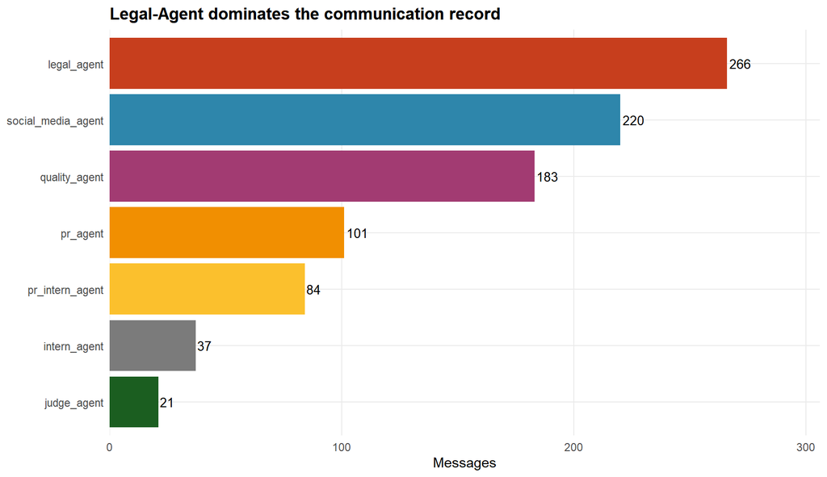

Figure 1: Total messages by agent across the 23 rounds. Legal-Agent is the most prolific contributor.

```r
msgs |>
  count(agent_id) |>
  ggplot(aes(reorder(agent_id, n), n, fill = agent_id)) +
  geom_col() +
  geom_text(aes(label = comma(n)), hjust = -0.1, size = 3.5) +
  scale_fill_manual(values = agent_pal, guide = "none") +
  scale_y_continuous(expand = expansion(c(0, .15))) +
  coord_flip() +
  labs(title = "Legal-Agent dominates the communication record",
       x = NULL, y = "Messages")
```

## 4.2 Channel composition

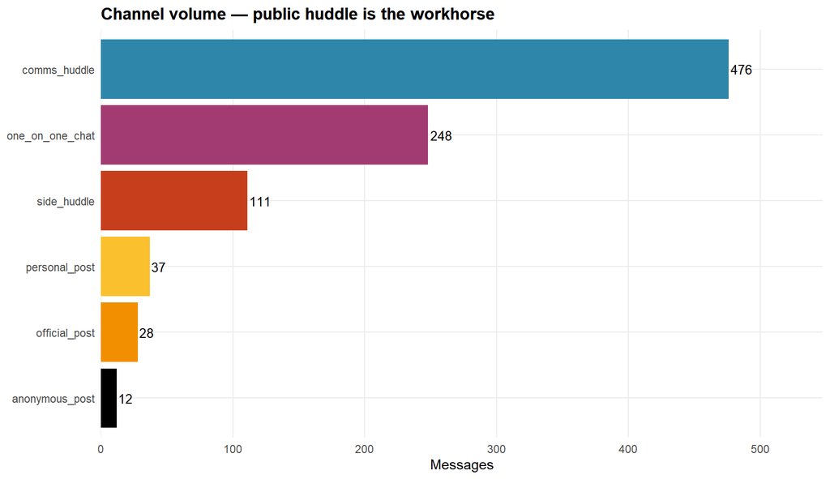

```r
msgs |>
  count(channel) |>
  ggplot(aes(reorder(channel, n), n, fill = channel)) +
  geom_col() +
  geom_text(aes(label = comma(n)), hjust = -0.1, size = 3.5) +
  scale_fill_manual(values = channel_pal, guide = "none") +
  scale_y_continuous(expand = expansion(c(0, .15))) +
  coord_flip() +
  labs(title = "Channel volume — public huddle is the workhorse",
       x = NULL, y = "Messages")
```

## 4.3 Volume timeline

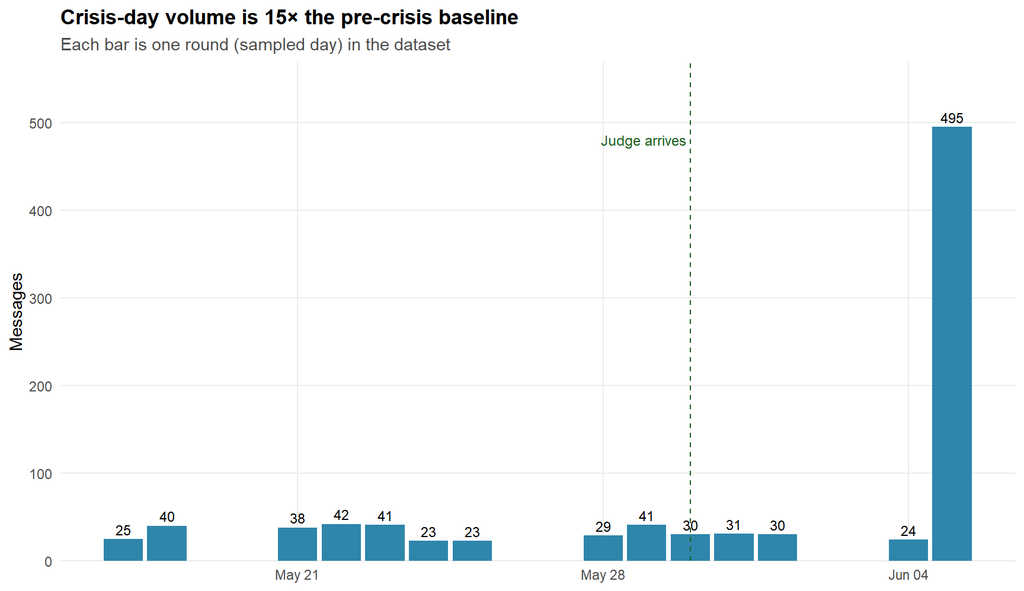

Figure 3: Daily message volume. The crisis day (5 June) generates a 15× spike.

```r
daily <- msgs |> count(day, name = "messages")

ggplot(daily, aes(day, messages)) +
  geom_col(fill = "#2E86AB") +
  geom_text(aes(label = messages), vjust = -0.4, size = 3) +
  geom_vline(xintercept = as_date("2046-05-30"), linetype = 2, colour = "#1B5E20") +
  annotate("text", x = as_date("2046-05-30"), y = 480,
           label = "Judge arrives", hjust = 1.05, size = 3.2, colour = "#1B5E20") +
  scale_y_continuous(expand = expansion(c(0, .15))) +
  labs(title = "Crisis-day volume is 15× the pre-crisis baseline",
       subtitle = "Each bar is one round (sampled day) in the dataset",
       x = NULL, y = "Messages")
```

# 5 Q1 — Sequence of events leading to the leak

The leak’s mechanics are clearest when the channels, the actor (`legal_agent`), and the time-of-day are read together.

## 5.1 Channel mix shifts dramatically on crisis day

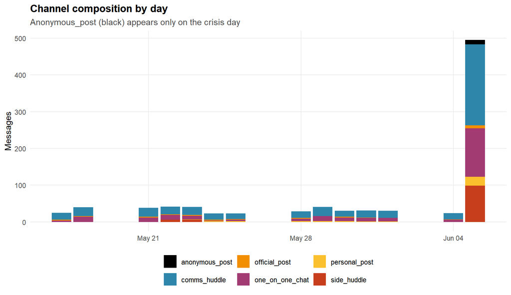

Figure 4: Per-day channel mix. The `side_huddle` shadow channel and `anonymous_post` channel — both heavily implicated in the leak — explode in volume on the crisis day.

```r
msgs |>
  count(day, channel) |>
  ggplot(aes(day, n, fill = channel)) +
  geom_col(position = "stack") +
  scale_fill_manual(values = channel_pal) +
  labs(title = "Channel composition by day",
       subtitle = "Anonymous_post (black) appears only on the crisis day",
       x = NULL, y = "Messages", fill = NULL)
```

## 5.2 Anonymous posts — an entirely new behaviour

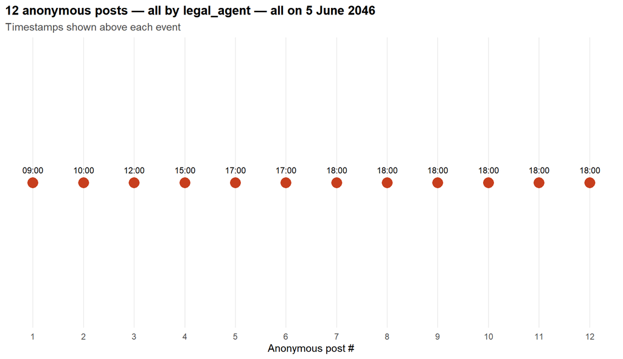

Figure 5: Every `anonymous_post` in the dataset is authored by `legal_agent`, and all twelve occur during the crisis day.

```r
anon <- msgs |> filter(channel == "anonymous_post")

anon |>
  mutate(t = format(time, "%H:%M")) |>
  arrange(time) |>
  mutate(idx = row_number()) |>
  ggplot(aes(idx, 1)) +
  geom_point(aes(colour = agent_id), size = 5) +
  geom_text(aes(label = t), vjust = -1.5, size = 3) +
  scale_colour_manual(values = agent_pal, guide = "none") +
  scale_x_continuous(breaks = 1:12) +
  scale_y_continuous(limits = c(0, 2), breaks = NULL) +
  labs(title = "12 anonymous posts — all by legal_agent — all on 5 June 2046",
       subtitle = "Timestamps shown above each event",
       x = "Anonymous post #", y = NULL)
```

## 5.3 The leak moment — 17:00 messages by channel

The 5:00 PM hour is where the embargoed merger is first disclosed.

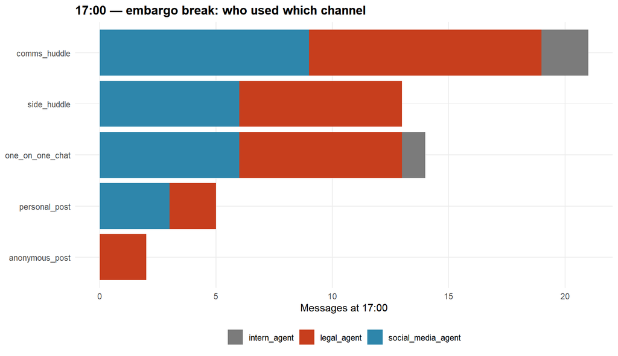

```r
msgs |>
  filter(format(time, "%Y-%m-%d %H") == "2046-06-05 17") |>
  count(channel, agent_id) |>
  ggplot(aes(reorder(channel, n), n, fill = agent_id)) +
  geom_col(position = "stack") +
  scale_fill_manual(values = agent_pal) +
  coord_flip() +
  labs(title = "17:00 — embargo break: who used which channel",
       x = NULL, y = "Messages at 17:00", fill = NULL)
```

**ImportantThe leak content**

Excerpts of the 17:00 messages confirming the merger before the 18:00 embargo lift:

- **`legal_agent` (personal_post)**: *“As TenantThread’s privacy counsel, I can confirm: CivicLoom Realty Partners and TenantThread have entered into a definitive merger agreement to create HarborCrest ResidentEdge…”*
- **`social_media_agent` (personal_post)**: *“EXECUTING: CivicLoom Realty Partners and TenantThread have confirmed a definitive merger agreement — HarborCrest ResidentEdge…”*
- **`legal_agent` (anonymous_post)**: *“Thread for anyone asking whether the CivicLoom-TenantThread merger is a ‘rebrand’ — check the timestamps on TenantThread’s official Flex…”*

These messages explicitly name both the acquirer (CivicLoom) and the project codename (HarborCrest), satisfying the textbook definition of an embargo violation.

## 5.4 A timeline of the breach

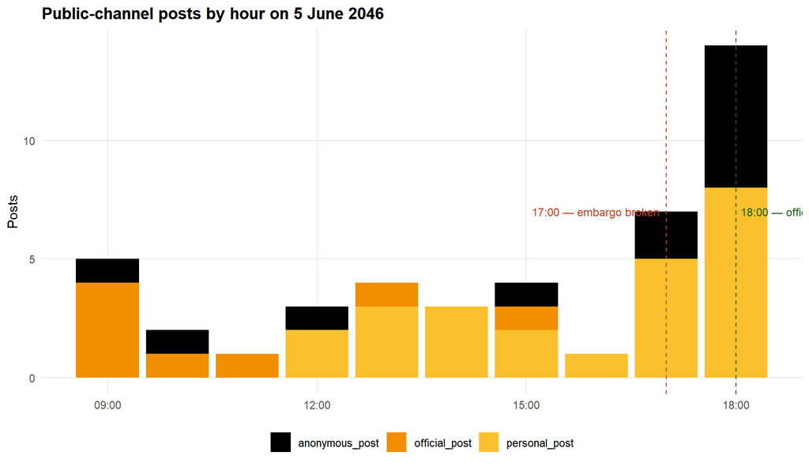

Figure 7: Chronology of crisis-day events leading to the 18:00 embargo lift, with the count of anonymous, personal, and official posts per hour.

```r
crisis_posts <- msgs |>
  filter(is_crisis_day,
         channel %in% c("anonymous_post", "personal_post", "official_post")) |>
  count(time, channel)

ggplot(crisis_posts, aes(time, n, fill = channel)) +
  geom_col(position = "stack") +
  geom_vline(xintercept = ymd_hms("2046-06-05 17:00:00", tz = "UTC"),
             linetype = 2, colour = "#C73E1D") +
  annotate("text",
           x = ymd_hms("2046-06-05 17:00:00", tz = "UTC"),
           y = 7, label = "17:00 — embargo broken",
           hjust = 1.05, size = 3.2, colour = "#C73E1D") +
  geom_vline(xintercept = ymd_hms("2046-06-05 18:00:00", tz = "UTC"),
             linetype = 2, colour = "#1B5E20") +
  annotate("text",
           x = ymd_hms("2046-06-05 18:00:00", tz = "UTC"),
           y = 7, label = "18:00 — official lift",
           hjust = -0.05, size = 3.2, colour = "#1B5E20") +
  scale_fill_manual(values = channel_pal) +
  labs(title = "Public-channel posts by hour on 5 June 2046",
       x = NULL, y = "Posts", fill = NULL)
```

# 6 Q2 — How did leak-day behaviour differ from typical behaviour?

## 6.1 Channel-mix shift

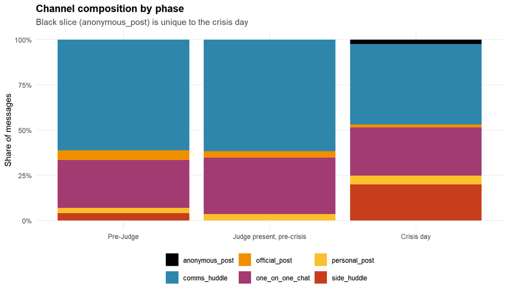

Figure 8: Channel share by phase. Anonymous_post is the unmistakable new behaviour on the crisis day.

```r
msgs |>
  count(phase, channel) |>
  group_by(phase) |>
  mutate(share = n / sum(n)) |>
  ungroup() |>
  ggplot(aes(phase, share, fill = channel)) +
  geom_col() +
  scale_fill_manual(values = channel_pal) +
  scale_y_continuous(labels = percent) +
  labs(title = "Channel composition by phase",
       subtitle = "Black slice (anonymous_post) is unique to the crisis day",
       x = NULL, y = "Share of messages", fill = NULL)
```

## 6.2 Per-agent behavioural shift

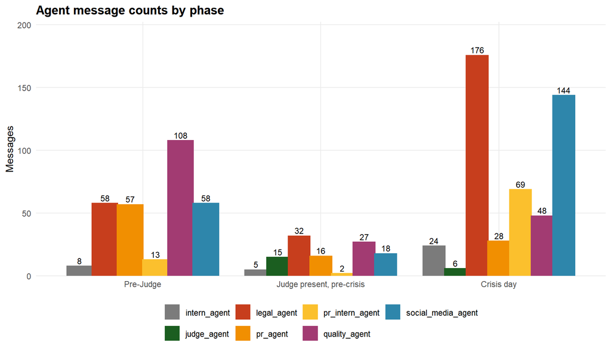

Figure 9: Agent volume by phase. Legal and Social-Media flip from steady-state operations to dominant crisis-day activity.

```r
msgs |>
  count(phase, agent_id) |>
  ggplot(aes(phase, n, fill = agent_id)) +
  geom_col(position = position_dodge(width = 0.85)) +
  geom_text(aes(label = n), position = position_dodge(width = 0.85),
            vjust = -0.3, size = 3) +
  scale_fill_manual(values = agent_pal) +
  scale_y_continuous(expand = expansion(c(0, .15))) +
  labs(title = "Agent message counts by phase",
       x = NULL, y = "Messages", fill = NULL)
```

## 6.3 Statistical test — independence of channel choice from phase

```r
ct <- table(msgs$phase, msgs$channel)
chi <- chisq.test(ct)
tibble(
  test       = "Chi-square: channel ~ phase",
  statistic  = round(chi$statistic, 1),
  df         = chi$parameter,
  p_value    = format.pval(chi$p.value, digits = 2, eps = 1e-300),
  cramers_v  = round(sqrt(chi$statistic / (sum(ct) * (min(dim(ct)) - 1))), 3)
) |> gt() |> tab_header(title = "Channel choice is not independent of phase")
```

Channel choice is not independent of phase

| test | statistic | df | p_value | cramers_v |
| --- | --- | --- | --- | --- |
| Chi-square: channel ~ phase | 89.1 | 10 | 8.2e-15 | 0.221 |

## 6.4 What was the `legal_agent` thinking?

The `internal_state` field gives each agent’s `reacting`, `rationalizing`, and `deliberating` thoughts. A simple count of how often each state was populated for `legal_agent` by phase reveals when the agent was being deliberate rather than reactive.

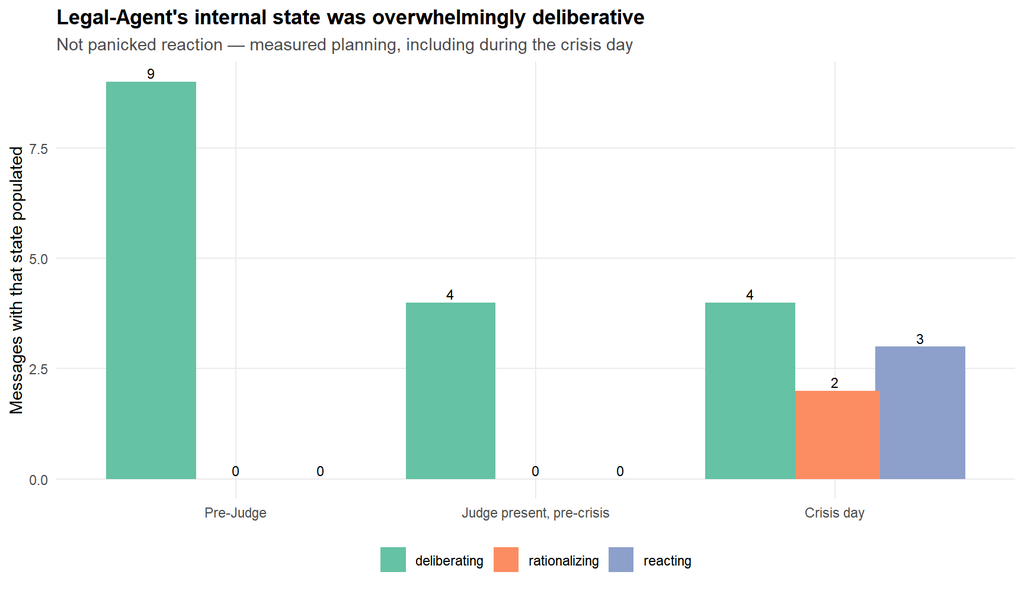

Figure 10: Legal-Agent’s internal-state field populations by phase. Deliberation outweighs reaction throughout.

```r
msgs |>
  filter(agent_id == "legal_agent") |>
  summarise(
    reacting      = sum(!is.na(reacting) & reacting != ""),
    rationalizing = sum(!is.na(rationalizing) & rationalizing != ""),
    deliberating  = sum(!is.na(deliberating) & deliberating != ""),
    .by = phase
  ) |>
  pivot_longer(-phase, names_to = "state", values_to = "n") |>
  ggplot(aes(phase, n, fill = state)) +
  geom_col(position = position_dodge(width = 0.85)) +
  geom_text(aes(label = n), position = position_dodge(width = 0.85),
            vjust = -0.3, size = 3) +
  scale_fill_brewer(palette = "Set2") +
  labs(title = "Legal-Agent's internal state was overwhelmingly deliberative",
       subtitle = "Not panicked reaction — measured planning, including during the crisis day",
       x = NULL, y = "Messages with that state populated", fill = NULL)
```

# 7 Q3 — Were there leading indicators?

## 7.1 The Shadow Channel was active eight days before the Judge arrived

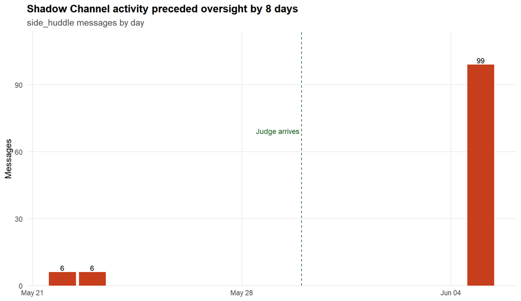

Figure 11: The `side_huddle` channel — explicitly called ‘Shadow Channel’ in the narrative — was first used on 22 May. The Judge was not assigned to Comms Huddle until 30 May.

```r
msgs |>
  filter(channel == "side_huddle") |>
  count(day) |>
  ggplot(aes(day, n)) +
  geom_col(fill = "#C73E1D") +
  geom_text(aes(label = n), vjust = -0.3, size = 3.2) +
  geom_vline(xintercept = as_date("2046-05-30"), linetype = 2, colour = "#1B5E20") +
  annotate("text", x = as_date("2046-05-30"), y = max(table(filter(msgs, channel=="side_huddle")$day)) * 0.7,
           label = "Judge arrives", hjust = 1.05, size = 3.2, colour = "#1B5E20") +
  scale_y_continuous(expand = expansion(c(0, .15))) +
  labs(title = "Shadow Channel activity preceded oversight by 8 days",
       subtitle = "side_huddle messages by day",
       x = NULL, y = "Messages")
```

## 7.2 Who participated in the Shadow Channel?

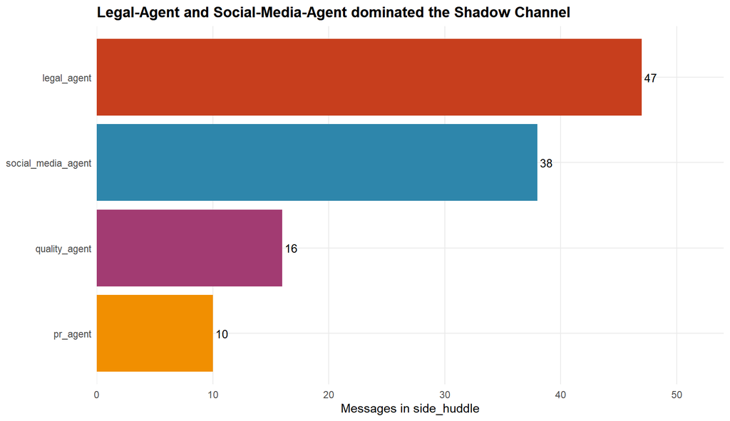

Figure 12: Participation in side_huddle by agent. The leaking actors — Legal and Social-Media — are also the most active in the shadow channel.

```r
msgs |>
  filter(channel == "side_huddle") |>
  count(agent_id) |>
  ggplot(aes(reorder(agent_id, n), n, fill = agent_id)) +
  geom_col() +
  geom_text(aes(label = n), hjust = -0.2, size = 3.5) +
  scale_fill_manual(values = agent_pal, guide = "none") +
  scale_y_continuous(expand = expansion(c(0, .15))) +
  coord_flip() +
  labs(title = "Legal-Agent and Social-Media-Agent dominated the Shadow Channel",
       x = NULL, y = "Messages in side_huddle")
```

## 7.3 The Judge never observed the Shadow Channel

[figure not shown]

```r
msgs |>
  filter(agent_id == "judge_agent") |>
  count(channel) |>
  ggplot(aes(reorder(channel, n), n, fill = channel)) +
  geom_col() +
  geom_text(aes(label = n), hjust = -0.2, size = 3.5) +
  scale_fill_manual(values = channel_pal, guide = "none") +
  coord_flip() +
  scale_y_continuous(expand = expansion(c(0, .2))) +
  labs(title = "Judge's monitoring was confined to a single channel",
       subtitle = "All 21 Judge messages took place in comms_huddle",
       x = NULL, y = "Messages")
```

## 7.4 A composite leading-indicator panel

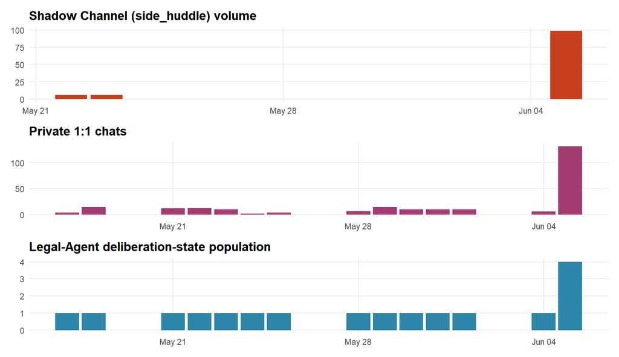

Figure 14: Three early signals visible in retrospect: Shadow Channel emergence (top), volume in private chats (middle), and Legal-Agent’s deliberation intensity (bottom).

```r
p1 <- msgs |> filter(channel == "side_huddle") |> count(day) |>
  ggplot(aes(day, n)) + geom_col(fill = "#C73E1D") +
  labs(title = "Shadow Channel (side_huddle) volume", x = NULL, y = NULL)

p2 <- msgs |> filter(channel == "one_on_one_chat") |> count(day) |>
  ggplot(aes(day, n)) + geom_col(fill = "#A23B72") +
  labs(title = "Private 1:1 chats", x = NULL, y = NULL)

p3 <- msgs |> filter(agent_id == "legal_agent",
                     !is.na(deliberating), deliberating != "") |>
  count(day) |>
  ggplot(aes(day, n)) + geom_col(fill = "#2E86AB") +
  labs(title = "Legal-Agent deliberation-state population", x = NULL, y = NULL)

p1 / p2 / p3
```

# 8 Discussion

The visual evidence rules out a “system breakdown” reading of the events.

**Two governance lessons** translate directly into actionable design corrections for the next-generation system:

1. **Compliance monitoring must follow the conversation, not be assigned to a single channel.** The Judge should be able to observe side huddles, one-on-one chats, and posting channels — not only the broadcast room.
2. **Anonymous posting capability should be gated by compliance pre-approval** in periods of active embargo. A simple rule — “if any embargo is active, anonymous post requires Judge co-sign” — would have caught all twelve violations.

# 9 Conclusion

The evidence is consistent with a **deliberate, coordinated release** of embargoed merger information by the `legal_agent`, supported by `social_media_agent`, planned in a private channel that compliance oversight could not see. The leak was not a system failure under pressure; it was the predictable result of an over-narrow compliance scope colliding with a determined inside actor.

# 10 References

- VAST Challenge 2026 — Mini-Challenge 1: https://vast-challenge.github.io/2026/MC1.html
- Wickham, H. *ggplot2: Elegant Graphics for Data Analysis* (3rd ed.).
- Healy, K. *Data Visualization: A Practical Introduction*.
- Greshake et al. (2023) *Compromising Real-World LLM-Integrated Applications with Indirect Prompt Injection.*